# Lab3

### Analisis de residuales

```r
predL<-predict(fitLPMW, newdata = test)
```

La prediccion se ve de esta manera

```r
head(predL)
```

```
##          1          3          7         14         18         19
##  0.4541690  0.4541690  1.0374299  0.4541690 -1.2956137 -0.7123528
```

```r
length(predL)
```

```
## [1] 337
```

```r
head(fitLPMW$residuals)
```

```
##         482          41         665          16          84         979
##  0.65034238 -0.17821426  1.82397072 -1.09882799  0.00142811  0.38589183
```

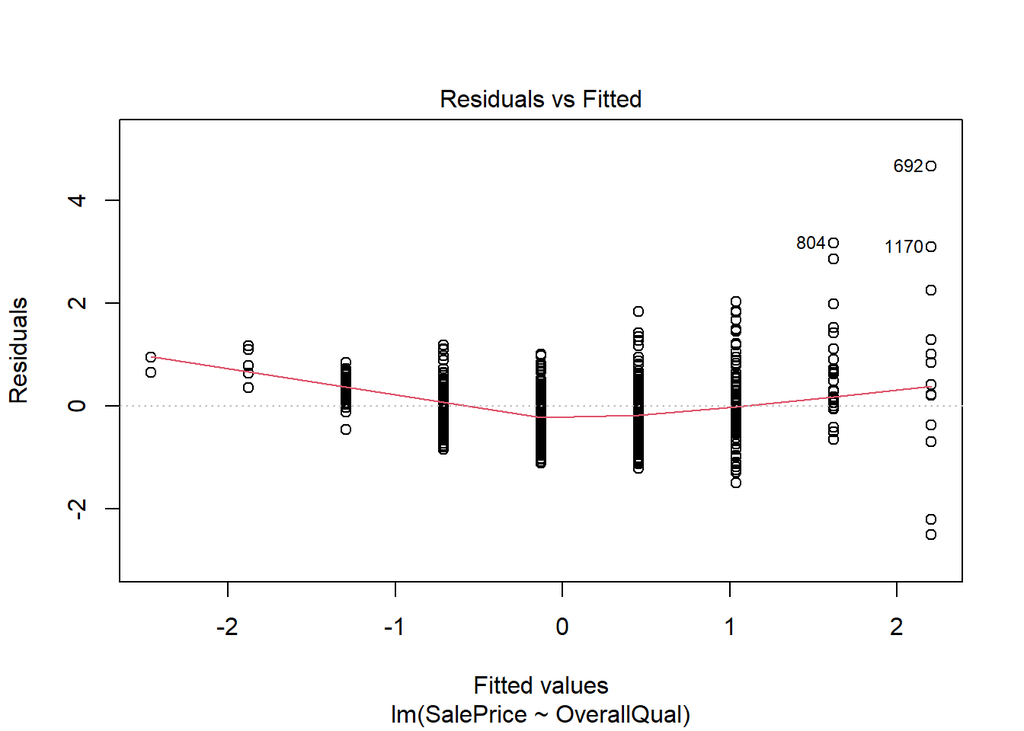

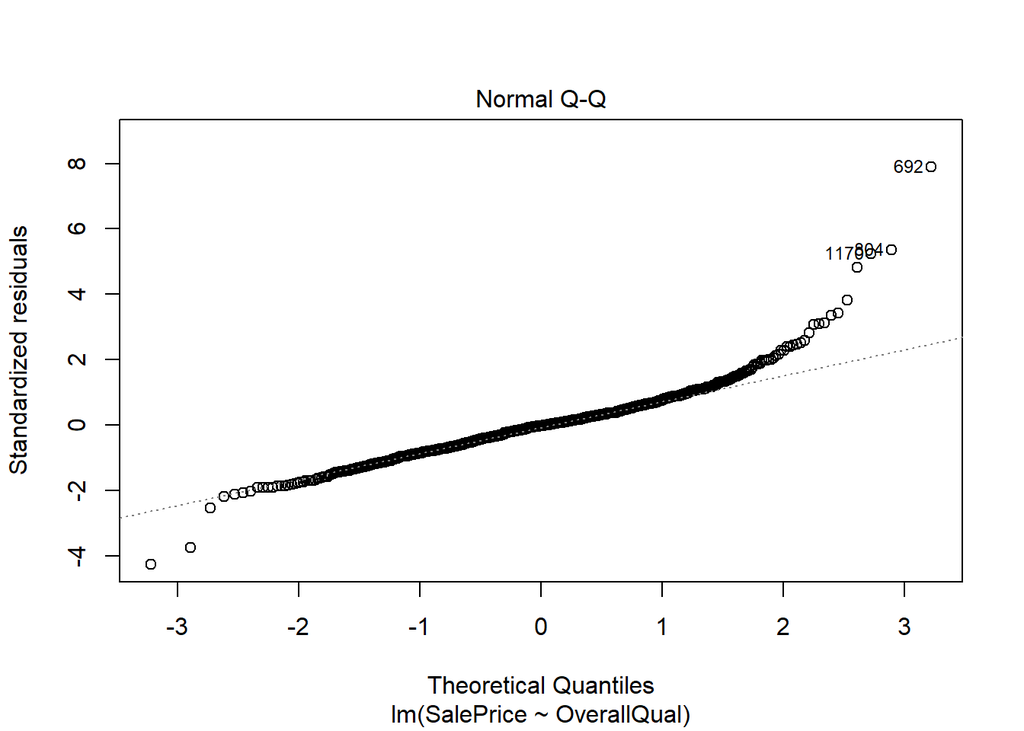

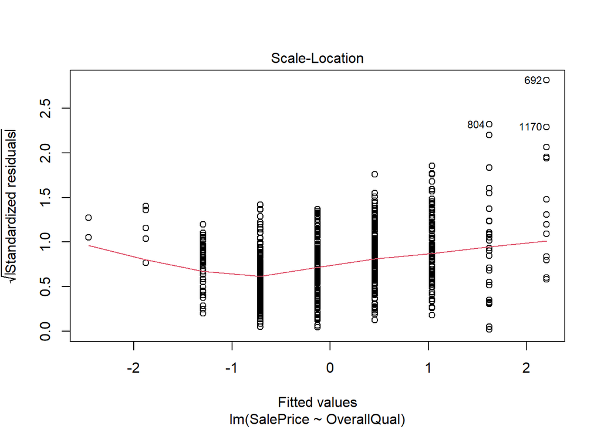

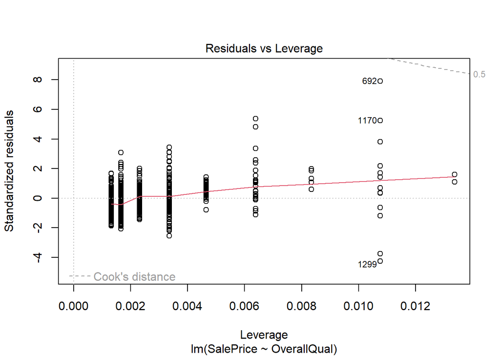

```r
plot(fitLPMW)
```

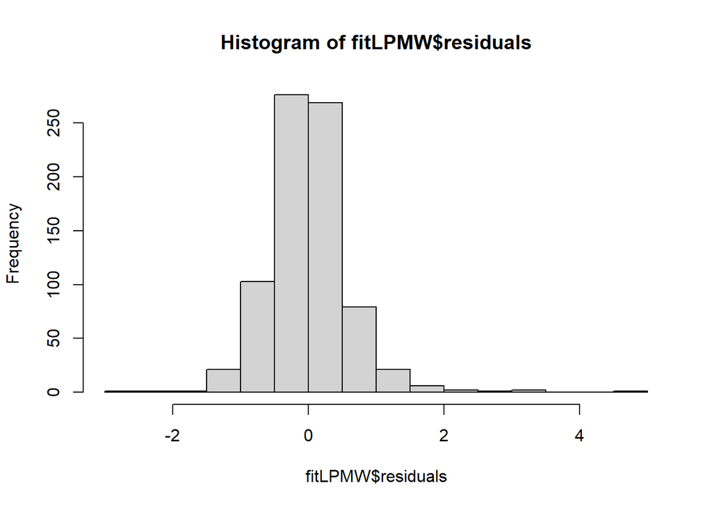

```r
hist(fitLPMW$residuals)
```

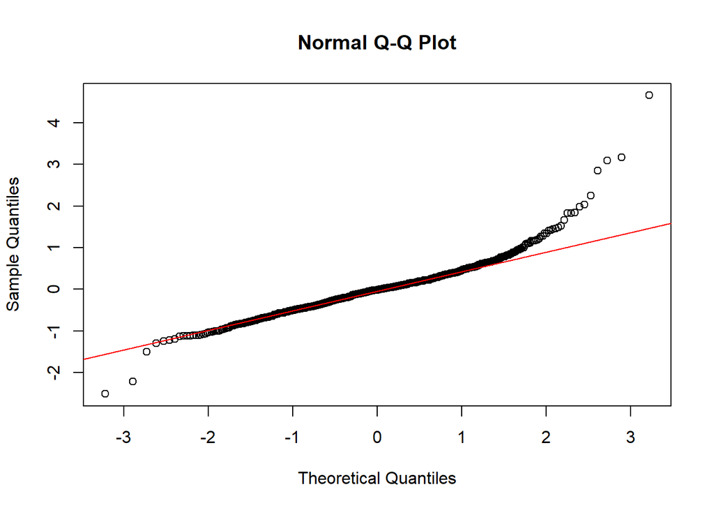

```r
qqnorm(fitLPMW$residuals)
qqline(fitLPMW$residuals, col="red")
```

```r
library(nortest)
lillie.test(fitLPMW$residuals)
```

```
##
##  Lilliefors (Kolmogorov-Smirnov) normality test
##
## data:  fitLPMW$residuals
## D = 0.083124, p-value = 5.391e-14
```

### Hallando el SalePrice para un cojunto de prueba

```r
predLM<-predict(fitLPMW, newdata = test[,c(1,2,4)])
```

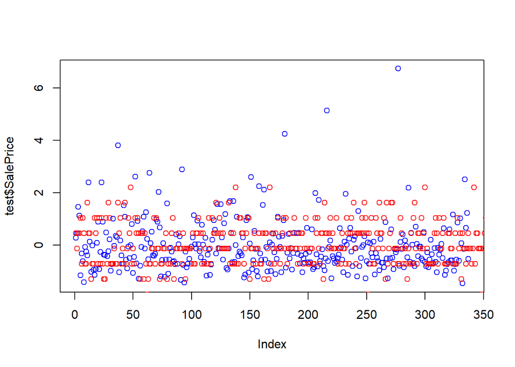

```r
plot(test$SalePrice,col="blue")
points(predLM, col="red")
```

## Regresion lineal multiple

```r
datos_df <- as.data.frame(datos_numericos)
multiples <-lm(SalePrice~.,data = datos_df)
```

### Resumen del modelo

```r
summary(multiples)
```

```
##
## Call:
## lm(formula = SalePrice ~ ., data = datos_df)
##
## Residuals:
##     Min      1Q  Median      3Q     Max
## -5.3276 -0.2043 -0.0340  0.1822  3.8336
##
## Coefficients: (2 not defined because of singularities)
##                 Estimate Std. Error t value Pr(>|t|)
## (Intercept)    2.366e-16  1.324e-02   0.000 1.000000
## Id            -6.111e-03  1.348e-02  -0.453 0.650332
## MSSubClass    -1.007e-01  1.737e-02  -5.797 8.84e-09 ***
## LotFrontage   -3.392e-02  1.791e-02  -1.894 0.058503 .
## LotArea        5.311e-02  1.543e-02   3.442 0.000599 ***
## OverallQual    3.104e-01  2.465e-02  12.592  < 2e-16 ***
## OverallCond    6.743e-02  1.760e-02   3.830 0.000135 ***
## YearBuilt      1.181e-01  3.271e-02   3.610 0.000321 ***
## YearRemodAdd   3.025e-02  2.196e-02   1.378 0.168607
## MasVnrArea     7.171e-02  1.603e-02   4.473 8.54e-06 ***
## BsmtFinSF1     9.794e-02  3.294e-02   2.973 0.003014 **
## BsmtFinSF2     1.586e-02  1.667e-02   0.952 0.341532
## BsmtUnfSF      2.715e-02  2.863e-02   0.948 0.343173
## TotalBsmtSF           NA         NA      NA       NA
## X1stFlrSF      2.139e-01  3.424e-02   6.246 6.02e-10 ***
## X2ndFlrSF      2.464e-01  3.224e-02   7.641 4.72e-14 ***
## LowQualFinSF   1.674e-02  1.400e-02   1.196 0.232009
## GrLivArea             NA         NA      NA       NA
## BsmtFullBath   5.582e-02  1.974e-02   2.828 0.004776 **
## BsmtHalfBath   6.907e-03  1.421e-02   0.486 0.627135
## FullBath       3.601e-02  2.340e-02   1.539 0.124182
## HalfBath      -6.600e-03  1.996e-02  -0.331 0.740945
## BedroomAbvGr  -9.504e-02  2.004e-02  -4.742 2.40e-06 ***
## KitchenAbvGr  -5.490e-02  1.673e-02  -3.282 0.001063 **
## TotRmsAbvGrd   1.048e-01  2.851e-02   3.674 0.000251 ***
## Fireplaces     3.332e-02  1.668e-02   1.998 0.046020 *
## GarageYrBlt   -1.471e-02  2.833e-02  -0.519 0.603742
## GarageCars     1.328e-01  2.752e-02   4.827 1.58e-06 ***
## GarageArea     1.446e-02  2.794e-02   0.517 0.605002
## WoodDeckSF     3.148e-02  1.472e-02   2.139 0.032662 *
## OpenPorchSF   -1.747e-03  1.512e-02  -0.116 0.907998
## EnclosedPorch  5.386e-03  1.523e-02   0.354 0.723590
## X3SsnPorch     1.201e-02  1.348e-02   0.891 0.373163
## ScreenPorch    4.042e-02  1.421e-02   2.844 0.004532 **
## PoolArea      -2.933e-02  1.449e-02  -2.024 0.043204 *
## MiscVal       -7.512e-03  1.390e-02  -0.540 0.589016
## MoSold        -7.179e-03  1.369e-02  -0.524 0.600188
## YrSold        -3.980e-03  1.360e-02  -0.293 0.769917
## ---
## Signif. codes:  0 '***' 0.001 '**' 0.01 '*' 0.05 '.' 0.1 ' ' 1
##
## Residual standard error: 0.4434 on 1085 degrees of freedom
## Multiple R-squared:  0.8096, Adjusted R-squared:  0.8034
## F-statistic: 131.8 on 35 and 1085 DF,  p-value: < 2.2e-16
```

Se puede mencionar que el r^2 para el segudo modelo es de 0.81

#Error medio cuadrtico del modelo mutiples

```r
mse2 <-mean(resid(multiples)^2)
mse2
```

```
## [1] 0.1902743
```

Se puede mencionar que el error medio cuadratico del modelo de multiples es de 0.19 #Error absoluto medio del modelo de multiples

```r
mae2 <-mean(abs(resid(multiples)))
mae2
```

```
## [1] 0.2669002
```

Se puede mencionar que el error absoluto medio del modelo de multiples es de 0.27

### Analisis de residuales segundo modelo

```r
predL2<-predict(multiples, newdata = test)
```

La prediccion se ve de esta manera

```r
head(predL2)
```

```
##          1          3          7         14         18         19
##  0.5707301  0.4846805  1.0836689  0.6544157 -1.2144886 -0.3563005
```

```r
length(predL2)
```

```
## [1] 337
```

```r
head(multiples$residuals)
```

```
##           1           2           3           4           5           6
## -0.29369296 -0.19802267 -0.02691865 -0.75421162 -0.59816724 -0.41585360
```

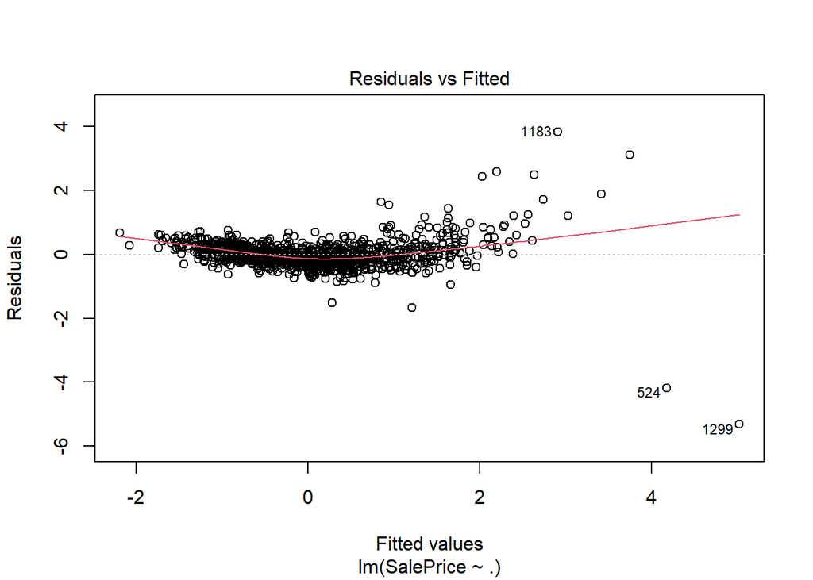

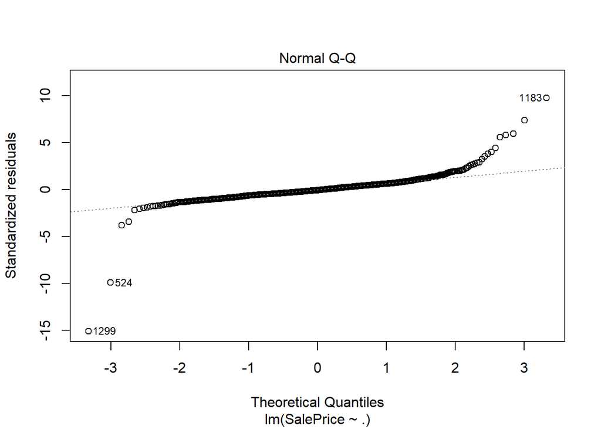

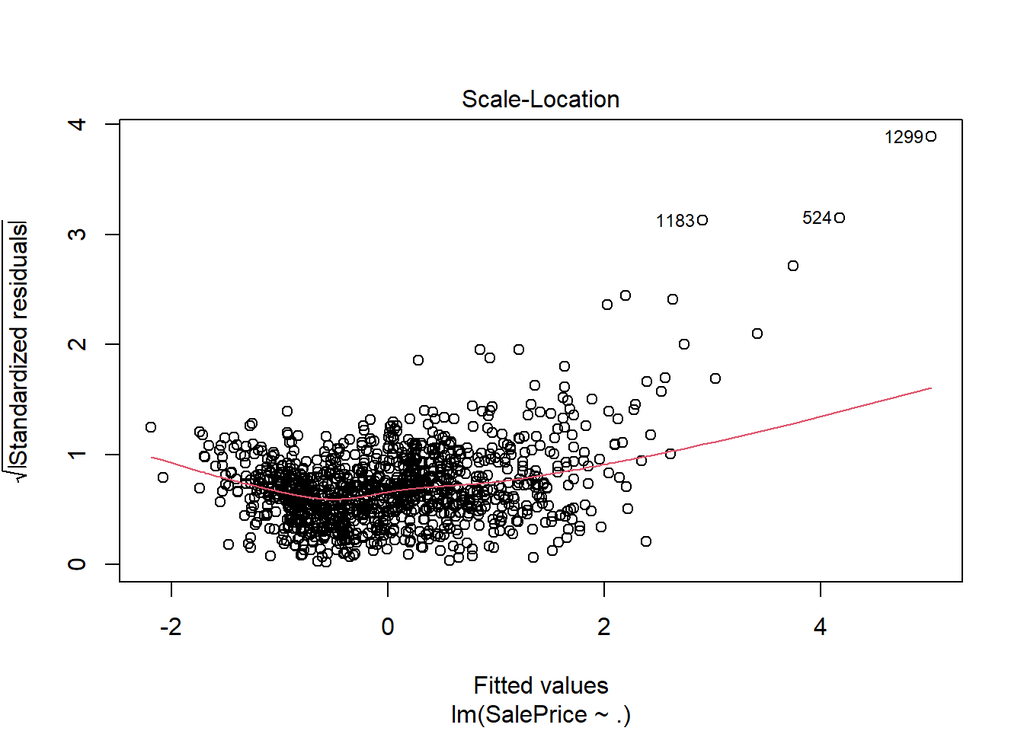

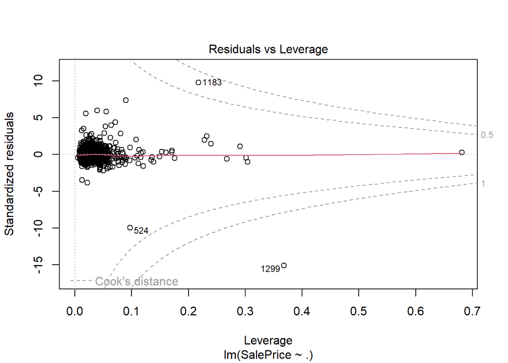

```r
plot(multiples)
```

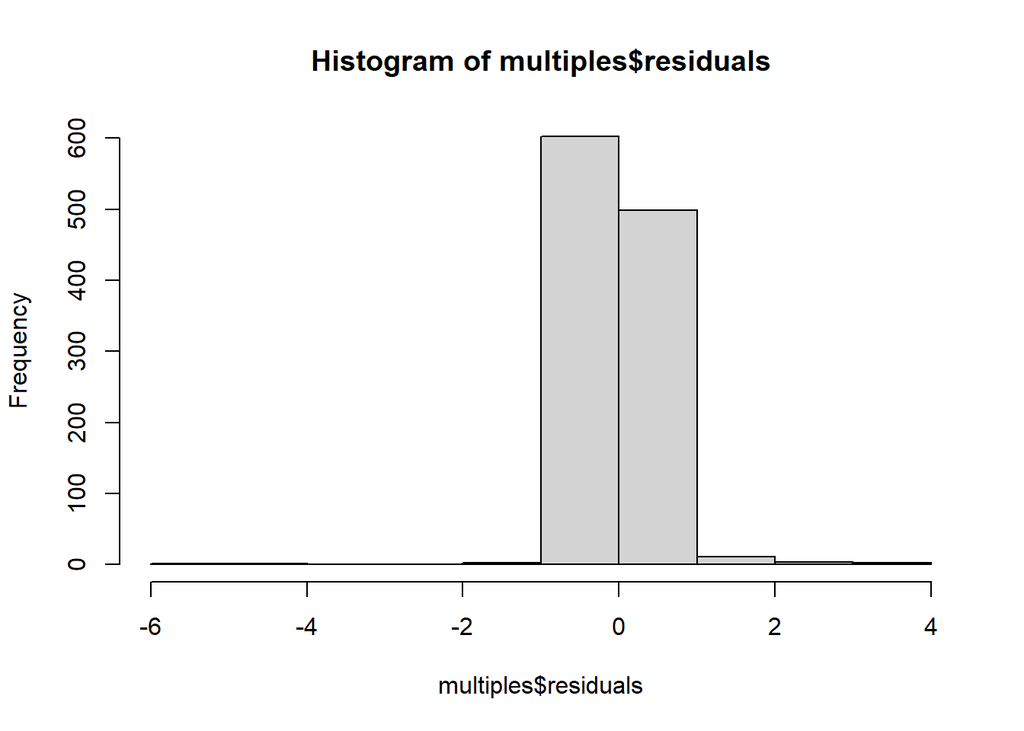

```r
hist(multiples$residuals)
```

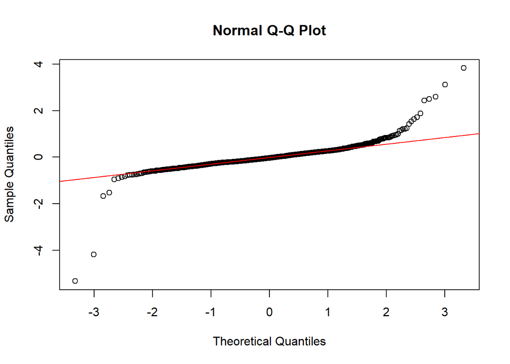

```r
qqnorm(multiples$residuals)
qqline(multiples$residuals, col="red")
```

```r
library(nortest)
lillie.test(multiples$residuals)
```

```
##
##  Lilliefors (Kolmogorov-Smirnov) normality test
##
## data:  multiples$residuals
## D = 0.11311, p-value < 2.2e-16
```